# Used Car Price Predictions Solution for the KaggleX Skill Assessment Challenge

by Salomon Marquez

25/06/2024

This notebook showcases my solution for the KaggleX Skill Assessment Challenge, a prerequisite to apply for the [KaggleX Fellowship Program](https://www.kaggle.com/kagglex). In this competition, I ranked 146th out of 1,846 participants.

My approach emphasized extensive feature engineering on the training dataset and augmenting it with additional data. For the model, I implemented a simple Multi-Layer Perceptron (MLP) to perform inference on the test dataset.

```python
# This Python 3 environment comes with many helpful analytics libraries installed
# It is defined by the kaggle/python Docker image: https://github.com/kaggle/docker-python
# For example, here's several helpful packages to load

import numpy as np # linear algebra
import pandas as pd # data processing, CSV file I/O (e.g. pd.read_csv)

# Input data files are available in the read-only "../input/" directory
# For example, running this (by clicking run or pressing Shift+Enter) will list all files under the input directory

import os
for dirname, _, filenames in os.walk('/kaggle/input'):
    for filename in filenames:
        print(os.path.join(dirname, filename))

# You can write up to 20GB to the current directory (/kaggle/working/) that gets preserved as output when you create a version using "Save & Run All"
# You can also write temporary files to /kaggle/temp/, but they won't be saved outside of the current session
```

# This Python 3 environment comes with many helpful analytics libraries installed # It is defined by the kaggle/python Docker image: https://github.com/kaggle/docker-python # For example, here's several helpful packages to load import numpy as np # linear algebra import pandas as pd # data processing, CSV file I/O (e.g. pd.read_csv) # Input data files are available in the read-only "../input/" directory # For example, running this (by clicking run or pressing Shift+Enter) will list all files under the input directory import os for dirname, _, filenames in os.walk('/kaggle/input'): for filename in filenames: print(os.path.join(dirname, filename)) # You can write up to 20GB to the current directory (/kaggle/working/) that gets preserved as output when you create a version using "Save & Run All" # You can also write temporary files to /kaggle/temp/, but they won't be saved outside of the current session

```
/kaggle/input/used-car-price-prediction-dataset-for-kagglex/sample_submission.csv
/kaggle/input/used-car-price-prediction-dataset-for-kagglex/used_cars.csv
/kaggle/input/used-car-price-prediction-dataset-for-kagglex/train.csv
/kaggle/input/used-car-price-prediction-dataset-for-kagglex/test.csv
```

```python
# Library Definition
import numpy as np
import pandas as pd
import seaborn as sns
import matplotlib.pyplot as plt
import re
from pandas.plotting import scatter_matrix

from sklearn.preprocessing import OneHotEncoder
from sklearn.impute import SimpleImputer
from sklearn.preprocessing import StandardScaler, RobustScaler
from sklearn.pipeline import make_pipeline
from sklearn.compose import ColumnTransformer
from sklearn.neural_network import MLPRegressor
from sklearn.metrics import mean_squared_error
from sklearn.model_selection import KFold, cross_val_score
import category_encoders as ce

from scipy.stats import skew
from scipy.special import boxcox1p
```

# Library Definition import numpy as np import pandas as pd import seaborn as sns import matplotlib.pyplot as plt import re from pandas.plotting import scatter_matrix from sklearn.preprocessing import OneHotEncoder from sklearn.impute import SimpleImputer from sklearn.preprocessing import StandardScaler, RobustScaler from sklearn.pipeline import make_pipeline from sklearn.compose import ColumnTransformer from sklearn.neural_network import MLPRegressor from sklearn.metrics import mean_squared_error from sklearn.model_selection import KFold, cross_val_score import category_encoders as ce from scipy.stats import skew from scipy.special import boxcox1p

## Loading Datasets

```python
train_df = pd.read_csv('/kaggle/input/used-car-price-prediction-dataset-for-kagglex/train.csv')
test_df = pd.read_csv('/kaggle/input/used-car-price-prediction-dataset-for-kagglex/test.csv')
dev_df = pd.read_csv('/kaggle/input/used-car-price-prediction-dataset-for-kagglex/used_cars.csv')
```

train_df = pd.read_csv('/kaggle/input/used-car-price-prediction-dataset-for-kagglex/train.csv') test_df = pd.read_csv('/kaggle/input/used-car-price-prediction-dataset-for-kagglex/test.csv') dev_df = pd.read_csv('/kaggle/input/used-car-price-prediction-dataset-for-kagglex/used_cars.csv')

## Joining Train and Dev Datasets

```python
# Function to extract numeric values from the mileage string
def extract_numeric_value(text):
    # Define a pattern to match numeric values
    pattern = r'[\d]+'
    # Use findall() function from the re package to extract all numeric values from the text and
    # join them into a single string
    return ''.join(re.findall(pattern, text))
```

# Function to extract numeric values from the mileage string def extract_numeric_value(text): # Define a pattern to match numeric values pattern = r'[\d]+' # Use findall() function from the re package to extract all numeric values from the text and # join them into a single string return ''.join(re.findall(pattern, text))

```python
# Apply the function to the DataFrame column
dev_df['milage'] = dev_df['milage'].apply(extract_numeric_value)

# Convert the mileage column to integer type
dev_df['milage'] = dev_df['milage'].astype(int)

# Apply the function to the DataFrame column
dev_df['price'] = dev_df['price'].apply(extract_numeric_value)

# Convert the mileage column to integer type
dev_df['price'] = dev_df['price'].astype(int)

# Define new index
start =  len(train_df)
end = len(train_df) + len(dev_df)

# Insert ID column in the beginning of the dev dataframe
dev_df.insert(0, 'id', range(start, end))

# Vertical concatenation
train2_df = pd.concat([train_df, dev_df])

# Reset Indexes
train2_df.reset_index(drop=True, inplace=True)
```

# Apply the function to the DataFrame column dev_df['milage'] = dev_df['milage'].apply(extract_numeric_value) # Convert the mileage column to integer type dev_df['milage'] = dev_df['milage'].astype(int) # Apply the function to the DataFrame column dev_df['price'] = dev_df['price'].apply(extract_numeric_value) # Convert the mileage column to integer type dev_df['price'] = dev_df['price'].astype(int) # Define new index start = len(train_df) end = len(train_df) + len(dev_df) # Insert ID column in the beginning of the dev dataframe dev_df.insert(0, 'id', range(start, end)) # Vertical concatenation train2_df = pd.concat([train_df, dev_df]) # Reset Indexes train2_df.reset_index(drop=True, inplace=True)

## Feature Engineering

### Categorical Features

```python
# Create brandmodel feature
train2_df["brandmodel"] = train2_df['brand']+ ' ' + train2_df['model']
train2_df[['brand','model','brandmodel']].head(3)
```

# Create brandmodel feature train2_df["brandmodel"] = train2_df['brand']+ ' ' + train2_df['model'] train2_df[['brand','model','brandmodel']].head(3)

|  | brand | model | brandmodel |
| --- | --- | --- | --- |
| 0 | Ford | F-150 Lariat | Ford F-150 Lariat |
| 1 | BMW | 335 i | BMW 335 i |
| 2 | Jaguar | XF Luxury | Jaguar XF Luxury |

```python
# Extract  HoursePower, Engine Displacements, and Number of Cylinders
def get_engine_features(text):

    #Regular expresion pattern to extract engine values
    hp_pattern = r'(\d+\.\d+)HP' # HorsePower
    ed_pattern = r'(\d+\.\d+)L'  # Engine Displacement
    cylinders_pattern = r'I(\d+)|V(\d+)|(\d+) Cylinder' # Number of Cylinders
    valves_pattern = r'(\d+)V' # Number of Valves

    # Search for the patterns in the string
    hp_match = re.search(hp_pattern, text)
    ed_match = re.search(ed_pattern, text)
    cylinders_match = re.search(cylinders_pattern, text)
    valves_match = re.search(valves_pattern, text)

    # Extract and convert the matched values
    if hp_match:
        hp = float(hp_match.group(1))
    else:
        hp = np.nan

    if ed_match:
        ed = float(ed_match.group(1))
    else:
        ed = np.nan

    if cylinders_match:
        cylinders = int(cylinders_match.group(cylinders_match.lastindex))
    else:
        cylinders = np.nan

    if valves_match:
        valves = int(valves_match.group(1))
    else:
        valves = np.nan

    return pd.Series({
        'hp': hp,
        'ed': ed,
        'num_cylinders': cylinders,
        'num_valves': valves
    })
```

# Extract HoursePower, Engine Displacements, and Number of Cylinders def get_engine_features(text): #Regular expresion pattern to extract engine values hp_pattern = r'(\d+\.\d+)HP' # HorsePower ed_pattern = r'(\d+\.\d+)L' # Engine Displacement cylinders_pattern = r'I(\d+)|V(\d+)|(\d+) Cylinder' # Number of Cylinders valves_pattern = r'(\d+)V' # Number of Valves # Search for the patterns in the string hp_match = re.search(hp_pattern, text) ed_match = re.search(ed_pattern, text) cylinders_match = re.search(cylinders_pattern, text) valves_match = re.search(valves_pattern, text) # Extract and convert the matched values if hp_match: hp = float(hp_match.group(1)) else: hp = np.nan if ed_match: ed = float(ed_match.group(1)) else: ed = np.nan if cylinders_match: cylinders = int(cylinders_match.group(cylinders_match.lastindex)) else: cylinders = np.nan if valves_match: valves = int(valves_match.group(1)) else: valves = np.nan return pd.Series({ 'hp': hp, 'ed': ed, 'num_cylinders': cylinders, 'num_valves': valves })

```python
# Apply extraction function
train2_df[['hp', 'ed', 'num_cylinders', 'num_valves']] = train2_df['engine'].apply(get_engine_features)

# Plot new features
train2_df[["hp", "ed", "num_cylinders", "num_valves"]].hist(bins=50, figsize=(6,4))
plt.show()
```

# Apply extraction function train2_df[['hp', 'ed', 'num_cylinders', 'num_valves']] = train2_df['engine'].apply(get_engine_features) # Plot new features train2_df[["hp", "ed", "num_cylinders", "num_valves"]].hist(bins=50, figsize=(6,4)) plt.show()

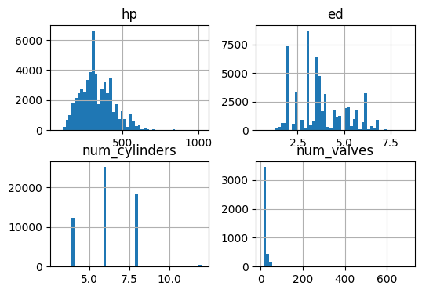

```python
# Function to transform transmission feature
def simple_transmission(text):

    # Patterns to identify
    patterns = {
        r'\b(automatic|a/t|at)\b':'automatic',
        r'\b(manual|m/t|mt)\b':'manual',
        r'\b(variable|cvt)\b':'cvt',
        r'\b(with|w/|at/mt)\b':'manumatic'
    }

    for pattern, replacement in patterns.items():
        if re.search(pattern, text, flags=re.IGNORECASE):
            return replacement

    return 'others'
```

# Function to transform transmission feature def simple_transmission(text): # Patterns to identify patterns = { r'\b(automatic|a/t|at)\b':'automatic', r'\b(manual|m/t|mt)\b':'manual', r'\b(variable|cvt)\b':'cvt', r'\b(with|w/|at/mt)\b':'manumatic' } for pattern, replacement in patterns.items(): if re.search(pattern, text, flags=re.IGNORECASE): return replacement return 'others'

```python
# Apply function
train2_df['transmission'] = train2_df['transmission'].apply(simple_transmission)
```

# Apply function train2_df['transmission'] = train2_df['transmission'].apply(simple_transmission)

### Numerical Features

```python
train2_df.info()
```

train2_df.info()

```
<class 'pandas.core.frame.DataFrame'>
RangeIndex: 58282 entries, 0 to 58281
Data columns (total 18 columns):
 #   Column         Non-Null Count  Dtype
---  ------         --------------  -----
 0   id             58282 non-null  int64
 1   brand          58282 non-null  object
 2   model          58282 non-null  object
 3   model_year     58282 non-null  int64
 4   milage         58282 non-null  int64
 5   fuel_type      58112 non-null  object
 6   engine         58282 non-null  object
 7   transmission   58282 non-null  object
 8   ext_col        58282 non-null  object
 9   int_col        58282 non-null  object
 10  accident       58169 non-null  object
 11  clean_title    57686 non-null  object
 12  price          58282 non-null  int64
 13  brandmodel     58282 non-null  object
 14  hp             53415 non-null  float64
 15  ed             57280 non-null  float64
 16  num_cylinders  57081 non-null  float64
 17  num_valves     4056 non-null   float64
dtypes: float64(4), int64(4), object(10)
memory usage: 8.0+ MB
```

```python
# Plot numerical features
train2_df[["model_year", "milage","hp", "ed", "num_cylinders", "num_valves"]].hist(bins=50, figsize=(8,8))
plt.show()
```

# Plot numerical features train2_df[["model_year", "milage","hp", "ed", "num_cylinders", "num_valves"]].hist(bins=50, figsize=(8,8)) plt.show()

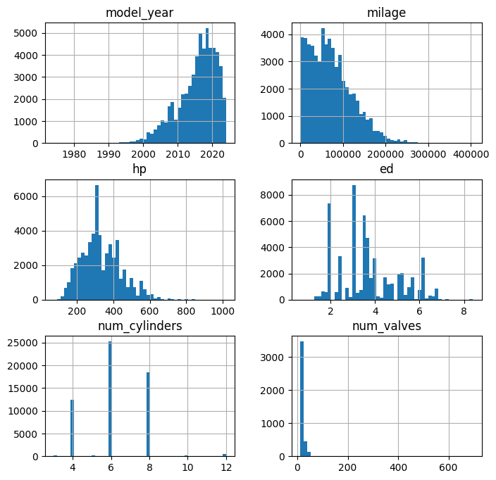

```python
# Plot scatter matrix
scatter_matrix(train2_df[["model_year", "milage","hp", "ed", "num_cylinders", "num_valves"]], figsize=(8,8))
plt.show()
```

# Plot scatter matrix scatter_matrix(train2_df[["model_year", "milage","hp", "ed", "num_cylinders", "num_valves"]], figsize=(8,8)) plt.show()

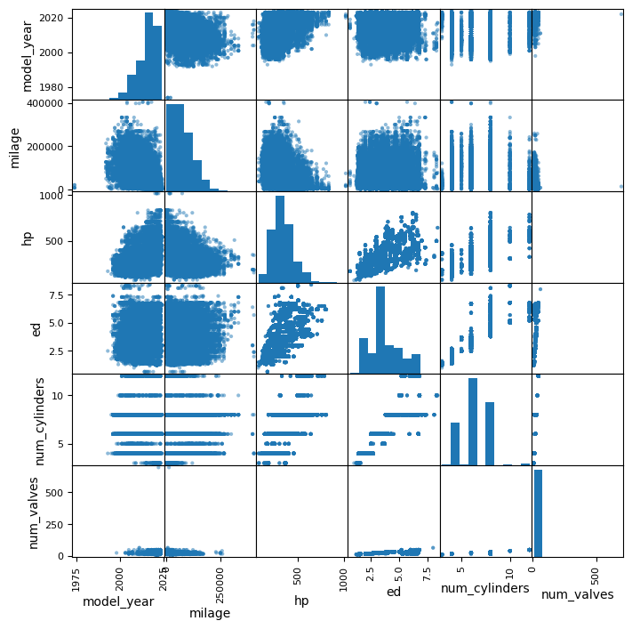

```python
# Check the skew of all numerical features
skewed_feats = train2_df[["model_year", "milage","hp", "ed", "num_cylinders", "num_valves"]].apply(lambda x: skew(x.dropna()))
print("\nSkew in numerical features: \n")
skewness = pd.DataFrame({'Skew' :skewed_feats})
skewness.head(10)
```

# Check the skew of all numerical features skewed_feats = train2_df[["model_year", "milage","hp", "ed", "num_cylinders", "num_valves"]].apply(lambda x: skew(x.dropna())) print("\nSkew in numerical features: \n") skewness = pd.DataFrame({'Skew' :skewed_feats}) skewness.head(10)

```
Skew in numerical features:
```

|  | Skew |
| --- | --- |
| model_year | -0.951024 |
| milage | 0.874905 |
| hp | 0.661737 |
| ed | 0.525690 |
| num_cylinders | 0.195700 |
| num_valves | 36.235544 |

```python
# Reduce skeweness
train2_df['milage']= train2_df['milage'].apply(lambda x: np.sqrt(x))

lambda_ = 0.15
train2_df['hp']= boxcox1p(train2_df['hp'], lambda_)
train2_df['ed']= boxcox1p(train2_df['ed'], lambda_)
```

# Reduce skeweness train2_df['milage']= train2_df['milage'].apply(lambda x: np.sqrt(x)) lambda_ = 0.15 train2_df['hp']= boxcox1p(train2_df['hp'], lambda_) train2_df['ed']= boxcox1p(train2_df['ed'], lambda_)

```python
# percentile
#model_year_quantile = train2_df["model_year"].quantile([0.0, 0.1, 0.2, 0.3, 0.4, 0.5, 0.6, 0.7, 0.8, 0.9, 1.0])
#model_year_quantile
```

# percentile #model_year_quantile = train2_df["model_year"].quantile([0.0, 0.1, 0.2, 0.3, 0.4, 0.5, 0.6, 0.7, 0.8, 0.9, 1.0]) #model_year_quantile

```python
train2_df['model_year'] = pd.cut(train2_df['model_year'],
                                        bins=[1974, 2007, 2011, 2013, 2015, 2016, 2018, 2019, 2020, 2021, 2024],
                                        labels=[2007, 2011, 2013, 2015, 2016, 2018, 2019, 2020, 2021, 2024])
```

train2_df['model_year'] = pd.cut(train2_df['model_year'], bins=[1974, 2007, 2011, 2013, 2015, 2016, 2018, 2019, 2020, 2021, 2024], labels=[2007, 2011, 2013, 2015, 2016, 2018, 2019, 2020, 2021, 2024])

```python
# percentile
#model_year_quantile = train2_df["model_year"].quantile([0.0, 0.25, 0.5, 0.75, 1.0])

#train2_df['model_year'] = pd.cut(train2_df['model_year'],
#                                        bins=[1974, 2012, 2016, 2019, 2024],
#                                        labels=[2012, 2016, 2019, 2024])

#train2_df["model_year_skew"].hist(bins=10, figsize=(6,2))
#plt.show()
```

# percentile #model_year_quantile = train2_df["model_year"].quantile([0.0, 0.25, 0.5, 0.75, 1.0]) #train2_df['model_year'] = pd.cut(train2_df['model_year'], # bins=[1974, 2012, 2016, 2019, 2024], # labels=[2012, 2016, 2019, 2024]) #train2_df["model_year_skew"].hist(bins=10, figsize=(6,2)) #plt.show()

```python
# Check the skew of all numerical features
skewed_box = train2_df[["model_year", "milage","hp", "ed", "num_cylinders", "num_valves"]].apply(lambda x: skew(x.dropna()))
print("\nSkew in numerical features: \n")
skewness_box = pd.DataFrame({'Skew' :skewed_box})
skewness_box.head(10)
```

# Check the skew of all numerical features skewed_box = train2_df[["model_year", "milage","hp", "ed", "num_cylinders", "num_valves"]].apply(lambda x: skew(x.dropna())) print("\nSkew in numerical features: \n") skewness_box = pd.DataFrame({'Skew' :skewed_box}) skewness_box.head(10)

```
Skew in numerical features:
```

|  | Skew |
| --- | --- |
| model_year | -0.292276 |
| milage | -0.080750 |
| hp | -0.140137 |
| ed | 0.094202 |
| num_cylinders | 0.195700 |
| num_valves | 36.235544 |

```python
# Plot numerical features
train2_df[["model_year", "milage","hp", "ed", "num_cylinders", "num_valves"]].hist(bins=50, figsize=(8,8))
plt.show()
```

# Plot numerical features train2_df[["model_year", "milage","hp", "ed", "num_cylinders", "num_valves"]].hist(bins=50, figsize=(8,8)) plt.show()

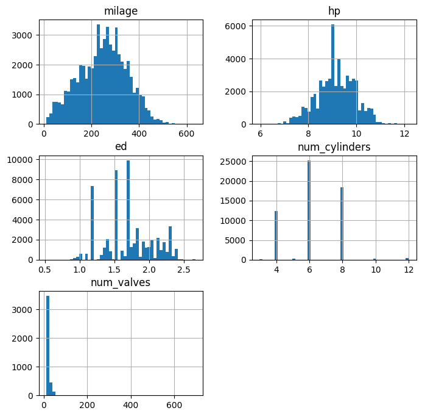

```python
train2_df.info()
```

train2_df.info()

```
<class 'pandas.core.frame.DataFrame'>
RangeIndex: 58282 entries, 0 to 58281
Data columns (total 18 columns):
 #   Column         Non-Null Count  Dtype
---  ------         --------------  -----
 0   id             58282 non-null  int64
 1   brand          58282 non-null  object
 2   model          58282 non-null  object
 3   model_year     58276 non-null  category
 4   milage         58282 non-null  float64
 5   fuel_type      58112 non-null  object
 6   engine         58282 non-null  object
 7   transmission   58282 non-null  object
 8   ext_col        58282 non-null  object
 9   int_col        58282 non-null  object
 10  accident       58169 non-null  object
 11  clean_title    57686 non-null  object
 12  price          58282 non-null  int64
 13  brandmodel     58282 non-null  object
 14  hp             53415 non-null  float64
 15  ed             57280 non-null  float64
 16  num_cylinders  57081 non-null  float64
 17  num_valves     4056 non-null   float64
dtypes: category(1), float64(5), int64(2), object(10)
memory usage: 7.6+ MB
```

## Principal Component Analysis

```python
from sklearn.decomposition import PCA
from sklearn.feature_selection import mutual_info_regression
from sklearn.model_selection import cross_val_score
from xgboost import XGBRegressor
```

from sklearn.decomposition import PCA from sklearn.feature_selection import mutual_info_regression from sklearn.model_selection import cross_val_score from xgboost import XGBRegressor

```python
def apply_pca(X, standardize=True):
    # Standardize
    if standardize:
        X = (X - X.mean(axis=0)) / X.std(axis=0)

    # Create principal components
    pca = PCA()
    X_pca = pca.fit_transform(X)

    # Convert to dataframe
    component_names = [f"PC{i+1}" for i in range(X_pca.shape[1])]
    X_pca = pd.DataFrame(X_pca, columns = component_names)

    # Creating loadings
    loadings = pd.DataFrame(
        pca.components_.T,
        columns=component_names,
        index=X.columns
    )
    return pca, X_pca, loadings

def plot_variance(pca, width=8, dpi=100):
    # Create figure
    fig, axs = plt.subplots(1, 2)
    n = pca.n_components_
    grid = np.arange(1, n+1)

    # Explained variance
    evr = pca.explained_variance_ratio_
    axs[0].bar(grid, evr)
    axs[0].set(
        xlabel="Component", title="% Explained Variance", ylim=(0.0, 1.0)
    )

    # Cumulative Variance
    cv = np.cumsum(evr)
    axs[1].plot(np.r_[0, grid], np.r_[0, cv], "o-")
    axs[1].set(
        xlabel="Component", title="% Cumulative Variance", ylim=(0.0, 1.0)
    )
    # Set up figure
    fig.set(figwidth=width, dpi=dpi)
    return axs

def make_mi_scores(X, y):
    X = X.copy()
    for colname in X.select_dtypes(["object", "category"]):
        X[colname], _ = X[colname].factorize()
    # All discrete features should now have integer dtypes
    discrete_features = [pd.api.types.is_integer_dtype(t) for t in X.dtypes]
    mi_scores = mutual_info_regression(X, y, discrete_features=discrete_features, random_state=0)
    mi_scores = pd.Series(mi_scores, name="MI Scores", index=X.columns)
    mi_scores = mi_scores.sort_values(ascending=False)
    return mi_scores


def score_dataset(X, y, model=XGBRegressor()):
    # Label encoding for categoricals
    for colname in X.select_dtypes(["category", "object"]):
        X[colname], _ = X[colname].factorize()
    # Metric for Housing competition is RMSLE (Root Mean Squared Log Error)
    score = cross_val_score(
        model, X, y, cv=5, scoring="neg_mean_squared_log_error",
    )
    score = -1 * score.mean()
    score = np.sqrt(score)
    return score
```

def apply_pca(X, standardize=True): # Standardize if standardize: X = (X - X.mean(axis=0)) / X.std(axis=0) # Create principal components pca = PCA() X_pca = pca.fit_transform(X) # Convert to dataframe component_names = [f"PC{i+1}" for i in range(X_pca.shape[1])] X_pca = pd.DataFrame(X_pca, columns = component_names) # Creating loadings loadings = pd.DataFrame( pca.components_.T, columns=component_names, index=X.columns ) return pca, X_pca, loadings def plot_variance(pca, width=8, dpi=100): # Create figure fig, axs = plt.subplots(1, 2) n = pca.n_components_ grid = np.arange(1, n+1) # Explained variance evr = pca.explained_variance_ratio_ axs[0].bar(grid, evr) axs[0].set( xlabel="Component", title="% Explained Variance", ylim=(0.0, 1.0) ) # Cumulative Variance cv = np.cumsum(evr) axs[1].plot(np.r_[0, grid], np.r_[0, cv], "o-") axs[1].set( xlabel="Component", title="% Cumulative Variance", ylim=(0.0, 1.0) ) # Set up figure fig.set(figwidth=width, dpi=dpi) return axs def make_mi_scores(X, y): X = X.copy() for colname in X.select_dtypes(["object", "category"]): X[colname], _ = X[colname].factorize() # All discrete features should now have integer dtypes discrete_features = [pd.api.types.is_integer_dtype(t) for t in X.dtypes] mi_scores = mutual_info_regression(X, y, discrete_features=discrete_features, random_state=0) mi_scores = pd.Series(mi_scores, name="MI Scores", index=X.columns) mi_scores = mi_scores.sort_values(ascending=False) return mi_scores def score_dataset(X, y, model=XGBRegressor()): # Label encoding for categoricals for colname in X.select_dtypes(["category", "object"]): X[colname], _ = X[colname].factorize() # Metric for Housing competition is RMSLE (Root Mean Squared Log Error) score = cross_val_score( model, X, y, cv=5, scoring="neg_mean_squared_log_error", ) score = -1 * score.mean() score = np.sqrt(score) return score

```python
features = [
    "milage",
    "model_year",
    "hp",
    "ed",
    "num_cylinders"
]

print("Correlation with Price:\n")
print(train2_df[features].corrwith(train2_df.price))
```

features = [ "milage", "model_year", "hp", "ed", "num_cylinders" ] print("Correlation with Price:\n") print(train2_df[features].corrwith(train2_df.price))

```
Correlation with Price:

milage          -0.285471
model_year       0.230884
hp               0.256449
ed               0.111935
num_cylinders    0.143659
dtype: float64
```

```python
X = train2_df.copy()
y = X.pop("price")
X = X.loc[:, features]
X['model_year']= X['model_year'].astype('float64')
```

X = train2_df.copy() y = X.pop("price") X = X.loc[:, features] X['model_year']= X['model_year'].astype('float64')

```python
X.info()
```

X.info()

```
<class 'pandas.core.frame.DataFrame'>
RangeIndex: 58282 entries, 0 to 58281
Data columns (total 5 columns):
 #   Column         Non-Null Count  Dtype
---  ------         --------------  -----
 0   milage         58282 non-null  float64
 1   model_year     58276 non-null  float64
 2   hp             53415 non-null  float64
 3   ed             57280 non-null  float64
 4   num_cylinders  57081 non-null  float64
dtypes: float64(5)
memory usage: 2.2 MB
```

```python
X.head(3)
```

X.head(3)

|  | milage | model_year | hp | ed | num_cylinders |
| --- | --- | --- | --- | --- | --- |
| 0 | 272.670130 | 2018.0 | 9.558416 | 1.687259 | 6.0 |
| 1 | 282.842712 | 2007.0 | 9.025890 | 1.540963 | 6.0 |
| 2 | 302.474792 | 2011.0 | 9.025890 | 1.870411 | 8.0 |

```python
# Create a pipeline for doing imputation and standard scaling
num_pipeline  = make_pipeline(SimpleImputer(strategy="median"), RobustScaler())
preprocessing = ColumnTransformer([("num", num_pipeline, features)])
```

# Create a pipeline for doing imputation and standard scaling num_pipeline = make_pipeline(SimpleImputer(strategy="median"), RobustScaler()) preprocessing = ColumnTransformer([("num", num_pipeline, features)])

```python
# Fit and transform the data
X_scaled = preprocessing.fit_transform(X)

# Create a new dataframe for scaled data
X_scaled_df = pd.DataFrame(X_scaled, columns=X.columns)
```

# Fit and transform the data X_scaled = preprocessing.fit_transform(X) # Create a new dataframe for scaled data X_scaled_df = pd.DataFrame(X_scaled, columns=X.columns)

```python
X_scaled_df.head(3)
```

X_scaled_df.head(3)

|  | milage | model_year | hp | ed | num_cylinders |
| --- | --- | --- | --- | --- | --- |
| 0 | 0.124850 | 0.333333 | 0.487727 | 0.000000 | 0.0 |
| 1 | 0.196527 | -1.500000 | -0.082593 | -0.344326 | 0.0 |
| 2 | 0.334855 | -0.833333 | -0.082593 | 0.431070 | 1.0 |

```python
# Apply pca
pca, X_pca, loadings = apply_pca(X_scaled_df)
print(loadings)
```

# Apply pca pca, X_pca, loadings = apply_pca(X_scaled_df) print(loadings)

```
                    PC1       PC2       PC3       PC4       PC5
milage        -0.263490  0.614072 -0.742920  0.004903  0.039187
model_year     0.223742 -0.644155 -0.610470 -0.395939  0.074582
hp             0.551986 -0.065634 -0.251091  0.783558 -0.118297
ed             0.528445  0.327686  0.046116 -0.428746 -0.653772
num_cylinders  0.544582  0.310313  0.101114 -0.213125  0.742624
```

```python
# Explained variance
plot_variance(pca);
```

# Explained variance plot_variance(pca);

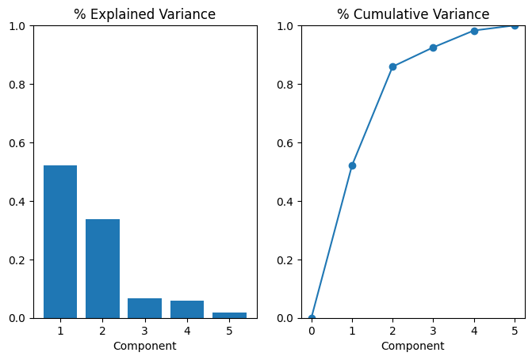

```python
sns.catplot(
    y="value",
    col="variable",
    data=X_pca.melt(),
    kind='boxen',
    sharey=False,
    col_wrap=3
);
```

sns.catplot( y="value", col="variable", data=X_pca.melt(), kind='boxen', sharey=False, col_wrap=3 );

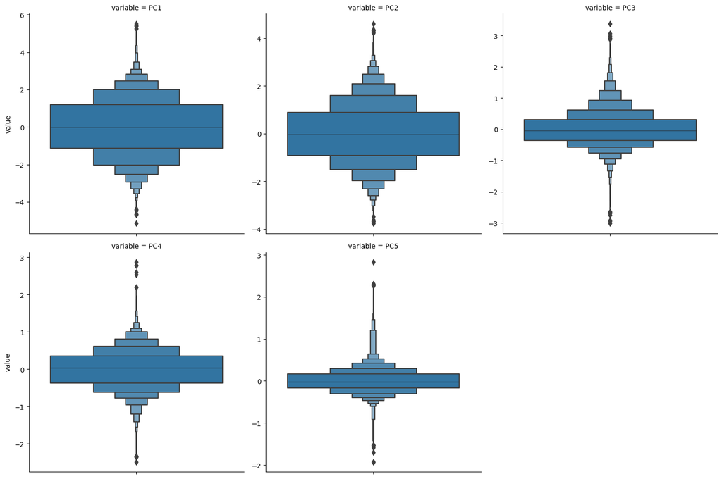

```python
train2_df.info()
```

train2_df.info()

```
<class 'pandas.core.frame.DataFrame'>
RangeIndex: 58282 entries, 0 to 58281
Data columns (total 18 columns):
 #   Column         Non-Null Count  Dtype
---  ------         --------------  -----
 0   id             58282 non-null  int64
 1   brand          58282 non-null  object
 2   model          58282 non-null  object
 3   model_year     58276 non-null  category
 4   milage         58282 non-null  float64
 5   fuel_type      58112 non-null  object
 6   engine         58282 non-null  object
 7   transmission   58282 non-null  object
 8   ext_col        58282 non-null  object
 9   int_col        58282 non-null  object
 10  accident       58169 non-null  object
 11  clean_title    57686 non-null  object
 12  price          58282 non-null  int64
 13  brandmodel     58282 non-null  object
 14  hp             53415 non-null  float64
 15  ed             57280 non-null  float64
 16  num_cylinders  57081 non-null  float64
 17  num_valves     4056 non-null   float64
dtypes: category(1), float64(5), int64(2), object(10)
memory usage: 7.6+ MB
```

```python
# Choose a component PC1, PC2, PC3, or PC4
component = "PC5"

idx = X_pca[component].sort_values(ascending=False).index
train2_df.loc[idx, ["price","brandmodel","fuel_type","transmission","ext_col","int_col","accident","clean_title"] + features]
```

# Choose a component PC1, PC2, PC3, or PC4 component = "PC5" idx = X_pca[component].sort_values(ascending=False).index train2_df.loc[idx, ["price","brandmodel","fuel_type","transmission","ext_col","int_col","accident","clean_title"] + features]

|  | price | brandmodel | fuel_type | transmission | ext_col | int_col | accident | clean_title | milage | model_year | hp | ed | num_cylinders |
| --- | --- | --- | --- | --- | --- | --- | --- | --- | --- | --- | --- | --- | --- |
| 56486 | 289991 | Bentley Continental GT GT Speed | Gasoline | automatic | Granite | Porpoise | None reported | NaN | 43.806392 | 2024 | NaN | NaN | 12.0 |
| 19906 | 16500 | BMW i3 94 Ah | Gasoline | automatic | Gray | Black | None reported | Yes | 288.097206 | 2016 | 7.749778 | 0.520063 | NaN |
| 57741 | 16500 | BMW i3 94 Ah | NaN | automatic | Black | – | None reported | Yes | 207.364414 | 2018 | 7.749778 | 0.520063 | NaN |
| 57363 | 26990 | BMW i3 120Ah w/Range Extender | NaN | automatic | Black | Black | None reported | Yes | 130.288142 | 2019 | 7.749778 | 0.520063 | NaN |
| 11599 | 11499 | BMW i3 Base w/Range Extender | Gasoline | automatic | White | Black | None reported | Yes | 272.946881 | 2015 | 7.749778 | 0.520063 | NaN |
| ... | ... | ... | ... | ... | ... | ... | ... | ... | ... | ... | ... | ... | ... |
| 42944 | 6699 | RAM 2500 Big Horn | Diesel | automatic | White | Gray | None reported | Yes | 311.448230 | 2007 | 9.391827 | 2.388206 | 6.0 |
| 48383 | 25500 | Dodge Ram 2500 Laramie Quad Cab | Diesel | automatic | Blue | Beige | None reported | Yes | 193.963914 | 2007 | 9.391827 | 2.388206 | 6.0 |
| 52980 | 69995 | RAM 3500 Tradesman | Diesel | automatic | Blue | Gray | None reported | Yes | 54.680892 | 2007 | 9.715842 | 2.388206 | 6.0 |
| 48311 | 1950995 | Bugatti Veyron 16.4 Grand Sport | Gasoline | automatic | White | Black | None reported | Yes | 79.561297 | 2011 | NaN | 2.602594 | NaN |
| 54502 | 1950995 | Bugatti Veyron 16.4 Grand Sport | Gasoline | automatic | White | White | None reported | Yes | 79.561297 | 2011 | NaN | 2.602594 | NaN |

58282 rows × 13 columns

## Dropping undesired features

```python
train2_df.info()
```

train2_df.info()

```
<class 'pandas.core.frame.DataFrame'>
RangeIndex: 58282 entries, 0 to 58281
Data columns (total 18 columns):
 #   Column         Non-Null Count  Dtype
---  ------         --------------  -----
 0   id             58282 non-null  int64
 1   brand          58282 non-null  object
 2   model          58282 non-null  object
 3   model_year     58276 non-null  category
 4   milage         58282 non-null  float64
 5   fuel_type      58112 non-null  object
 6   engine         58282 non-null  object
 7   transmission   58282 non-null  object
 8   ext_col        58282 non-null  object
 9   int_col        58282 non-null  object
 10  accident       58169 non-null  object
 11  clean_title    57686 non-null  object
 12  price          58282 non-null  int64
 13  brandmodel     58282 non-null  object
 14  hp             53415 non-null  float64
 15  ed             57280 non-null  float64
 16  num_cylinders  57081 non-null  float64
 17  num_valves     4056 non-null   float64
dtypes: category(1), float64(5), int64(2), object(10)
memory usage: 7.6+ MB
```

```python
# Drop undesired columns
car_labels = train2_df['price']
car_labels = car_labels.to_frame()

# Drop undesired features
train2_df.drop(['price','id','brand','model','engine','num_valves'], axis=1, inplace=True)
#train2_df.drop(['price','id','brand','model','engine','hp','ed','num_valves','num_cylinders'], axis=1, inplace=True)
```

# Drop undesired columns car_labels = train2_df['price'] car_labels = car_labels.to_frame() # Drop undesired features train2_df.drop(['price','id','brand','model','engine','num_valves'], axis=1, inplace=True) #train2_df.drop(['price','id','brand','model','engine','hp','ed','num_valves','num_cylinders'], axis=1, inplace=True)

```python
train2_df.info()
```

train2_df.info()

```
<class 'pandas.core.frame.DataFrame'>
RangeIndex: 58282 entries, 0 to 58281
Data columns (total 12 columns):
 #   Column         Non-Null Count  Dtype
---  ------         --------------  -----
 0   model_year     58276 non-null  category
 1   milage         58282 non-null  float64
 2   fuel_type      58112 non-null  object
 3   transmission   58282 non-null  object
 4   ext_col        58282 non-null  object
 5   int_col        58282 non-null  object
 6   accident       58169 non-null  object
 7   clean_title    57686 non-null  object
 8   brandmodel     58282 non-null  object
 9   hp             53415 non-null  float64
 10  ed             57280 non-null  float64
 11  num_cylinders  57081 non-null  float64
dtypes: category(1), float64(4), object(7)
memory usage: 4.9+ MB
```

```python
# Total imputation
train2_df = train2_df.replace('–', np.nan)
```

# Total imputation train2_df = train2_df.replace('–', np.nan)

```python
# Run this cell for joining the additional features from the PCA analysis
#train2_df = train2_df.join(X_pca)
```

# Run this cell for joining the additional features from the PCA analysis #train2_df = train2_df.join(X_pca)

```python
train2_df.info()
```

train2_df.info()

```
<class 'pandas.core.frame.DataFrame'>
RangeIndex: 58282 entries, 0 to 58281
Data columns (total 12 columns):
 #   Column         Non-Null Count  Dtype
---  ------         --------------  -----
 0   model_year     58276 non-null  category
 1   milage         58282 non-null  float64
 2   fuel_type      57773 non-null  object
 3   transmission   58282 non-null  object
 4   ext_col        58226 non-null  object
 5   int_col        57104 non-null  object
 6   accident       58169 non-null  object
 7   clean_title    57686 non-null  object
 8   brandmodel     58282 non-null  object
 9   hp             53415 non-null  float64
 10  ed             57280 non-null  float64
 11  num_cylinders  57081 non-null  float64
dtypes: category(1), float64(4), object(7)
memory usage: 4.9+ MB
```

## Builiding a Pipeline

```python
# Processing Pipeline
#num_features = ['model_year', 'milage','hp','ed','num_cylinders','PC1','PC2','PC3','PC4']
num_features = ['model_year', 'milage','hp','ed','num_cylinders']
cat_features = ['brandmodel','fuel_type','transmission','ext_col', 'int_col','accident','clean_title']

num_pipeline = make_pipeline(SimpleImputer(strategy="median"), RobustScaler())
cat_pipeline = make_pipeline(SimpleImputer(strategy="most_frequent"), OneHotEncoder(handle_unknown='ignore'))

preprocessing = ColumnTransformer([
    ("num", num_pipeline, num_features),
    ("cat", cat_pipeline, cat_features)])
```

# Processing Pipeline #num_features = ['model_year', 'milage','hp','ed','num_cylinders','PC1','PC2','PC3','PC4'] num_features = ['model_year', 'milage','hp','ed','num_cylinders'] cat_features = ['brandmodel','fuel_type','transmission','ext_col', 'int_col','accident','clean_title'] num_pipeline = make_pipeline(SimpleImputer(strategy="median"), RobustScaler()) cat_pipeline = make_pipeline(SimpleImputer(strategy="most_frequent"), OneHotEncoder(handle_unknown='ignore')) preprocessing = ColumnTransformer([ ("num", num_pipeline, num_features), ("cat", cat_pipeline, cat_features)])

## Model Implementation

```python
# MLP Model
mlp_reg = MLPRegressor(
    hidden_layer_sizes = [8,32,8],   # [8,32,8], [8,32,64,32,8],[8,64,8]
    activation ='relu',
    solver = 'adam',
    alpha = 0.001,
    batch_size = 64,  # 32,64,128
    learning_rate = 'constant',
    max_iter = 400,
    shuffle = True,
    early_stopping = True,
    validation_fraction = 0.1,
    random_state=42)
pipeline = make_pipeline(preprocessing, mlp_reg)
```

# MLP Model mlp_reg = MLPRegressor( hidden_layer_sizes = [8,32,8], # [8,32,8], [8,32,64,32,8],[8,64,8] activation ='relu', solver = 'adam', alpha = 0.001, batch_size = 64, # 32,64,128 learning_rate = 'constant', max_iter = 400, shuffle = True, early_stopping = True, validation_fraction = 0.1, random_state=42) pipeline = make_pipeline(preprocessing, mlp_reg)

```python
pipeline.fit(train2_df, car_labels)
```

pipeline.fit(train2_df, car_labels)

```
Pipeline(steps=[('columntransformer',
                 ColumnTransformer(transformers=[('num',
                                                  Pipeline(steps=[('simpleimputer',
                                                                   SimpleImputer(strategy='median')),
                                                                  ('robustscaler',
                                                                   RobustScaler())]),
                                                  ['model_year', 'milage', 'hp',
                                                   'ed', 'num_cylinders']),
                                                 ('cat',
                                                  Pipeline(steps=[('simpleimputer',
                                                                   SimpleImputer(strategy='most_frequent')),
                                                                  ('onehotencoder',
                                                                   OneHotEncoder(handle_unknown='ignore'))]),
                                                  ['brandmodel', 'fuel_type',
                                                   'transmission', 'ext_col',
                                                   'int_col', 'accident',
                                                   'clean_title'])])),
                ('mlpregressor',
                 MLPRegressor(alpha=0.001, batch_size=64, early_stopping=True,
                              hidden_layer_sizes=[8, 32, 8], max_iter=400,
                              random_state=42))])
```

## Score a Baseline

```python
# Define K-Fold Cross Validator
kf = KFold(n_splits=5, shuffle=True, random_state=42)

# Perform cross-validation
baseline_scores = -cross_val_score(pipeline, train2_df, car_labels, scoring='neg_root_mean_squared_error', cv=kf)
print("Cross-Validation RMSE scores:", baseline_scores)
print("Average RMSE:", np.mean(baseline_scores))
```

# Define K-Fold Cross Validator kf = KFold(n_splits=5, shuffle=True, random_state=42) # Perform cross-validation baseline_scores = -cross_val_score(pipeline, train2_df, car_labels, scoring='neg_root_mean_squared_error', cv=kf) print("Cross-Validation RMSE scores:", baseline_scores) print("Average RMSE:", np.mean(baseline_scores))

```
Cross-Validation RMSE scores: [60193.71277415 78966.61767177 77424.15910457 48134.62743974
 72502.42776201]
Average RMSE: 67444.30895044885
```

```python
pd.Series(baseline_scores).describe()
```

pd.Series(baseline_scores).describe()

```
count        5.000000
mean     67444.308950
std      13070.773870
min      48134.627440
25%      60193.712774
50%      72502.427762
75%      77424.159105
max      78966.617672
dtype: float64
```

```python
pipeline.get_feature_names_out
```

pipeline.get_feature_names_out

```
<bound method Pipeline.get_feature_names_out of Pipeline(steps=[('columntransformer',
                 ColumnTransformer(transformers=[('num',
                                                  Pipeline(steps=[('simpleimputer',
                                                                   SimpleImputer(strategy='median')),
                                                                  ('robustscaler',
                                                                   RobustScaler())]),
                                                  ['model_year', 'milage', 'hp',
                                                   'ed', 'num_cylinders']),
                                                 ('cat',
                                                  Pipeline(steps=[('simpleimputer',
                                                                   SimpleImputer(strategy='most_frequent')),
                                                                  ('onehotencoder',
                                                                   OneHotEncoder(handle_unknown='ignore'))]),
                                                  ['brandmodel', 'fuel_type',
                                                   'transmission', 'ext_col',
                                                   'int_col', 'accident',
                                                   'clean_title'])])),
                ('mlpregressor',
                 MLPRegressor(alpha=0.001, batch_size=64, early_stopping=True,
                              hidden_layer_sizes=[8, 32, 8], max_iter=400,
                              random_state=42))])>
```

## Evaluate Model on RMSE

```python
# Predict train2_df prices 67277.4197309128 | 67308.44019387408 | 67231.14714140317
car_price_prediction = pipeline.predict(train2_df)

# Model evaluation
lm_rmse = mean_squared_error(car_labels, car_price_prediction, squared=False)
lm_rmse
```

# Predict train2_df prices 67277.4197309128 | 67308.44019387408 | 67231.14714140317 car_price_prediction = pipeline.predict(train2_df) # Model evaluation lm_rmse = mean_squared_error(car_labels, car_price_prediction, squared=False) lm_rmse

```
67454.88485800906
```

## Test Dataset

### Feature Engineering of Categorical Features

```python
test_df = pd.read_csv('/kaggle/input/used-car-price-prediction-dataset-for-kagglex/test.csv')
```

test_df = pd.read_csv('/kaggle/input/used-car-price-prediction-dataset-for-kagglex/test.csv')

```python
# Create brandmodel feature
test_df["brandmodel"] = test_df['brand']+ ' ' + test_df['model']

# Create engine additional features
test_df[['hp', 'ed', 'num_cylinders', 'num_valves']] = test_df['engine'].apply(get_engine_features)

# Create transmission features
test_df['transmission'] = test_df['transmission'].apply(simple_transmission)
```

# Create brandmodel feature test_df["brandmodel"] = test_df['brand']+ ' ' + test_df['model'] # Create engine additional features test_df[['hp', 'ed', 'num_cylinders', 'num_valves']] = test_df['engine'].apply(get_engine_features) # Create transmission features test_df['transmission'] = test_df['transmission'].apply(simple_transmission)